# Machine Learning Assignment

John Hansen

October 18, 2015

## Background

Using devices such as Jawbone Up, Nike FuelBand, and Fitbit it is now possible to collect a large amount of data about personal activity relatively inexpensively. These type of devices are part of the “quantified self” movement – a group of enthusiasts who take measurements about themselves regularly to improve their health, to find patterns in their behavior, or because they are tech geeks. One thing that people regularly do is quantify how much of a particular activity they do, but they rarely quantify how well they do it. In this project, your goal will be to use data from accelerometers on the belt, forearm, arm, and dumbell of 6 participants. They were asked to perform barbell lifts correctly and incorrectly in 5 different ways. More information is available from the website here: http://groupware.les.inf.puc-rio.br/har (see the section on the Weight Lifting Exercises Dataset).

## Data

The training data for this project are available here: https://d396qusza40orc.cloudfront.net/predmachlearn/pml-training.csv

The test data for this project are available here: https://d396qusza40orc.cloudfront.net/predmachlearn/pml-testing.csv

The data for this project come from this source: http://groupware.les.inf.puc-rio.br/har

and is used with the generous permission of these authors:  
> Velloso, E.; Bulling, A.; Gellersen, H.; Ugulino, W.; Fuks, H.

## Setup

First, we load the `caret` and `randomForest` libraries, and set our working directory.

```r
setwd("~/Google Drive/School/coursera/SigTrack8 - Machine Learning/assignment")
library(caret)
library(randomForest)
```

Then the text files with the data are loaded.

```r
pmlTraining <- read.csv("pml-training.csv", header = TRUE, na.strings = c("NA",""))
pmlTesting  <- read.csv("pml-testing.csv", header = TRUE, na.strings = c("NA",""))
```

The training dataset, called `pmlTraining` has 19622 records with 160 variables and the testing set `pmlTesting` has 20 records and 160 variables.

Not all variables contain information useful for modeling so the first task for processing will be to remove these non-contributory variables.

```r
pmlTrainingColFilter <- pmlTraining[,(colSums(is.na(pmlTraining)) == 0)]
pmlTestingColFilter  <- pmlTesting[,(colSums(is.na(pmlTesting)) == 0)]
removeCol <- c("X","user_name","raw_timestamp_part_1","raw_timestamp_part_2","cvtd_timestamp","new_window")
pmlTrainingColFilter <- pmlTrainingColFilter[,!(names(pmlTrainingColFilter) %in% removeCol)]
pmlTestingColFilter <- pmlTestingColFilter[,!(names(pmlTestingColFilter) %in% removeCol)]
```

The training and testing datasets now have had their width diminished to 54 and 54 each.

## Training a model

We will partition 70% of the training dataset into a portion for training a data model and reserve 30% for validation. We are setting a seed so that each time we do this we can expect to get the same results (I was wondering why the model I saved and then reloaded later performed so differently when I reloaded it!).

```r
set.seed(666)
inTrain = createDataPartition(y = pmlTrainingColFilter$classe, p = 0.7, list = FALSE)
training   <- pmlTrainingColFilter[ inTrain,]
validation <- pmlTrainingColFilter[-inTrain,]
```

Note that the `training` set has 13737 records now and the `validation` has 5885 - the `training` set has 70.0081541% of the former set of records.

## Pre-processing

Although the study authors were likely trying to improve the workouts of the studied athletes, we are merely trying to model in order to predict the workout class of a test dataset. Thus, interpretability of our model is not that important and we can use Principle Components Analysis to turn our test dataset into a weighted combination of predictor variables (the same must be done to the validation dataset). The fact that they are difficult to interpret does not matter. Note that later the same pre-processing will be imposed on the test dataset, called `pmlTestingColFilter`.

```r
preProcessed <- preProcess(training[, -54], method = "pca", thresh = 0.99)
trainPCA <- predict(preProcessed, training[, -54])
validPCA <- predict(preProcessed, validation[, -54])
```

## Modeling

To create a model we will use the random forest method. This takes quite a bit of time so I saved the results using the command `saveRDS(model,"model.rds")` statement, and loading it later using `model <- readRDS("model.rds")`. As I have run this previously I am now merely loading the stored `model` object.

```
model <- train(training$classe ~ ., method = "rf", data = trainPCA, trControl = trainControl(method = "cv", number = 4), importance = TRUE)
saveRDS(model,"model.rds")
```

```r
model <- readRDS("model.rds")
```

## Model evaluation

First, we will use a plot that will show us which components are the most important.

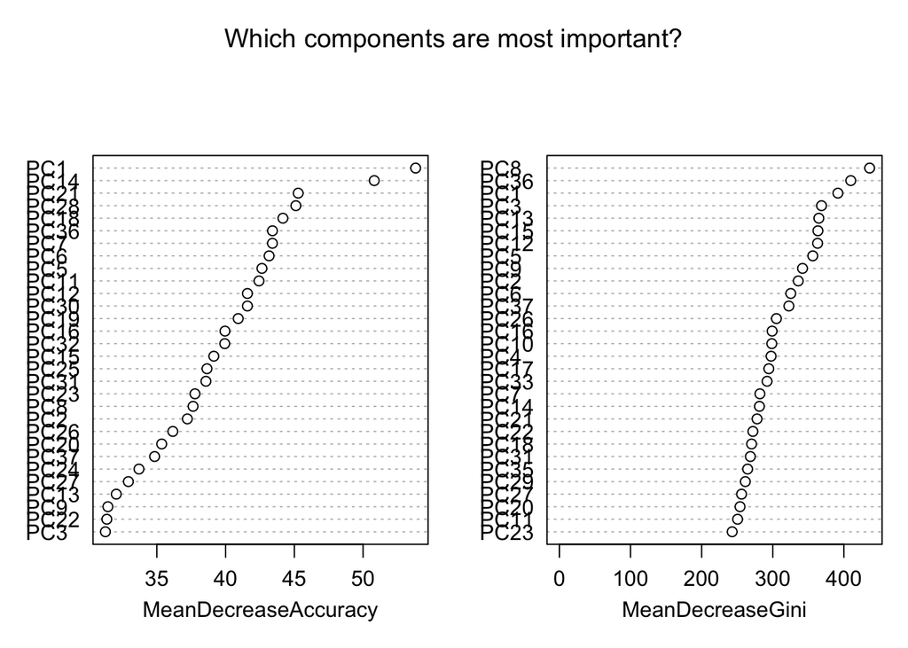

```r
varImpPlot(model$finalModel, main="Which components are most important?")
```

## Predicting on the validation set

Now we will use the predicted model on the validation set, and compare with the actual classes, examining the results. Results off of the diagonal are misclassification.

```r
predValid <- predict(model, validPCA)
confusion <- confusionMatrix(validation$classe, predValid)
confusion$table
```

```
##           Reference
## Prediction    A    B    C    D    E
##          A 1671    1    2    0    0
##          B   17 1114    6    0    2
##          C    0    8 1012    6    0
##          D    1    0   43  917    3
##          E    0    2    5   10 1065
```

We can examine the accuracy using the `postResample` method.

```r
accuracy <- postResample(validation$classe, predValid)
modelAccuracy <- accuracy[[1]]
modelError <- 1 - modelAccuracy
```

The resulting model was 98.1988105% accurate when used in the validation sample, meaning that we can expect an out-of-sample error of [1 minus that figure], or 1.8011895%.

## Model vs. test dataset

Now we use the model to predict class for the test dataset of 20 records.

```r
testPCA <- predict(preProcessed, pmlTestingColFilter[, -54])
final <- predict(model, testPCA)
```

And the model predicts the class for these 20 records as: B, A, B, A, A, C, D, B, A, A, B, C, B, A, E, E, A, B, B, B. When compared with the answers at the `Course Project: Submission` page it was not perfect, but predicted 19/20 correctly.

Thanks!